# PROYECTO INFERENCIA ESTADISTICA-NETFLIX

Diana Balanta-Danna Espinosa-Cristian Perafan-Geovanny Quintero

# **Objetivo 04.**

## **Identificar entre 6 géneros cuál tiene el mayor puntaje IMDb score promedio.**

**Generos:** Acción y aventura, niños y peliculas familiares, comedia,documentales,drama, horror.

## **Anova**

$\mu_1 =$ “score de los productos audiovisuales del género acción y aventura”

$\mu_2 =$ “score de los productos audiovisuales del género niños y peliculas familiares”

$\mu_3 =$ “score de los productos audiovisuales del género comedia”

$\mu_4 =$ “score de los productos audiovisuales del género documentales”

$\mu_5 =$ “score de los productos audiovisuales del género dramas”

$\mu_5 =$ “score de los productos audiovisuales del género peliculas de horror”

**Planteamiento de hipótesis**

$H_0$: $\mu_1 = \mu_2 = \mu_3 = \mu_4 = \mu_5 = \mu_6$ ““No existe diferencia entre la media de los score de los diferentes géneros”

$H_a$: “Por lo menos un par de medias de los scores de los géneros son diferentes”

**Criterio de rechazo:**

Rechazo $H_0$ SII $VrP < \alpha$

**Implementación en R:**

```r
library(readxl)
library(rapportools)


rutaExcel <-file.choose()

anovaData <- read_excel(rutaExcel,sheet = "Anova")

attach(anovaData)

anova <- aov(Score~Genres)
summary(anova)
```

```
##             Df Sum Sq Mean Sq F value  Pr(>F)
## Genres       5  25.07   5.015   6.567 6.2e-05 ***
## Residuals   60  45.82   0.764
## ---
## Signif. codes:  0 '***' 0.001 '**' 0.01 '*' 0.05 '.' 0.1 ' ' 1
```

**Análisis de resultados:**

Del anterior resumen generado por R podemos obtener $VrP$, evaluamos el $VrP$ en nuestro criterio de rechazo:

Con un nivel de significancia de 5%, hay suficiente evidencia para rechazar la HO, por lo tanto existe por lo menos una diferencia entre el score de un par de generos.

**Post Anova**

```r
TukeyHSD(anova)
```

```
##   Tukey multiple comparisons of means
##     95% family-wise confidence level
##
## Fit: aov(formula = Score ~ Genres)
##
## $Genres
##                               diff        lwr         upr     p adj
## Comedies-AyA           -0.37272727 -1.4696134  0.72415881 0.9160403
## CyF-AyA                -0.06363636 -1.1605225  1.03324972 0.9999787
## Documentaries-AyA       0.46363636 -0.6332497  1.56052245 0.8132209
## Dramas-AyA             -0.02727273 -1.1241588  1.06961336 0.9999997
## Horror-AyA             -1.51818182 -2.6150679 -0.42129573 0.0018337
## CyF-Comedies            0.30909091 -0.7877952  1.40597700 0.9608371
## Documentaries-Comedies  0.83636364 -0.2605225  1.93324972 0.2332953
## Dramas-Comedies         0.34545455 -0.7514315  1.44234063 0.9379424
## Horror-Comedies        -1.14545455 -2.2423406 -0.04856846 0.0357300
## Documentaries-CyF       0.52727273 -0.5696134  1.62415881 0.7178359
## Dramas-CyF              0.03636364 -1.0605225  1.13324972 0.9999987
## Horror-CyF             -1.45454545 -2.5514315 -0.35765937 0.0031753
## Dramas-Documentaries   -0.49090909 -1.5877952  0.60597700 0.7742730
## Horror-Documentaries   -1.98181818 -3.0787043 -0.88493209 0.0000234
## Horror-Dramas          -1.49090909 -2.5877952 -0.39402300 0.0023244
```

**Gráfico de diferencias**

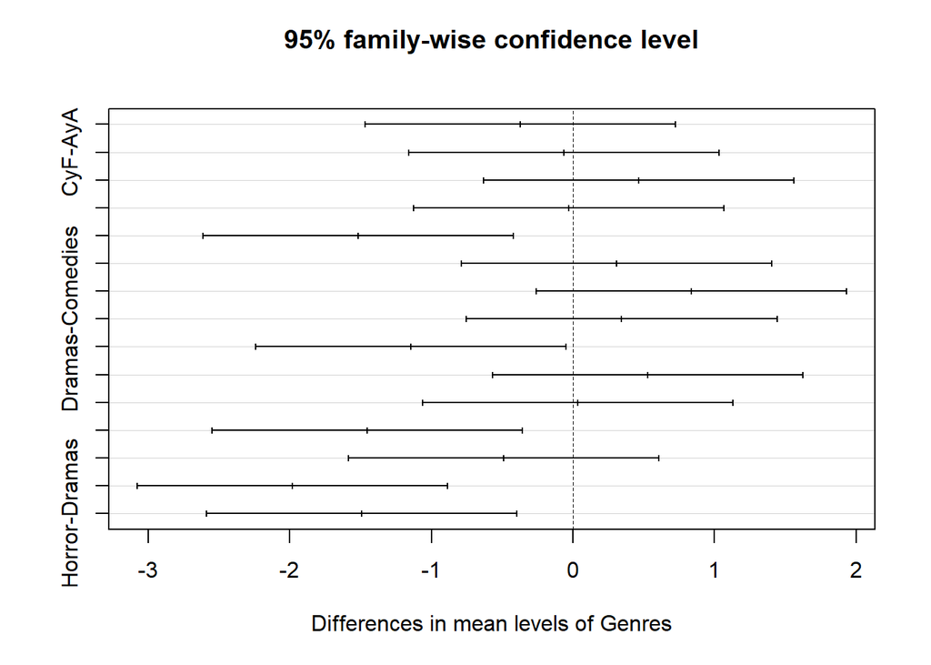

```r
plot(TukeyHSD(anova))
```

**Análisis PostAnova**

[output not shown]

Con base a la tabla se deduce entonces que: *Documentaries>Action & Adventure>Dramas>Children & Family>Comedies>Horror Movies.*

**Concluyendo, se define que las producciones de tipo Documentaries tienen el mayor puntaje IMDb score promedio, mientras que las de Horror Movies el menor puntaje IMDb promedio.**

**Diagrama de cajas**

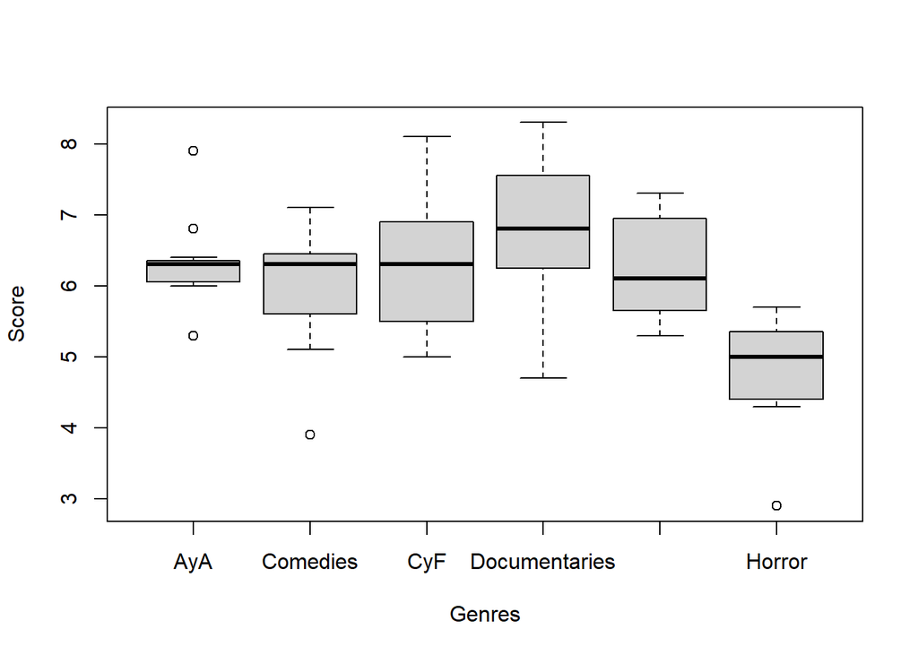

```r
boxplot(Score~Genres)
```

Los datos coinciden con el diagrama de cajas, ya que se puede observar como la media del score de Documentaries es la mayor y la media de Horror movies es la menor. También gracias a los intervalos se deduce que la media con mayor diferencia entre todas es la de horror movies, mientras las demás tienen un comportamiento similar.

# **Objetivo 05**

## **Conocer si existe relación entre el género de la película y el continente donde se produjo. (Prueba de independencia)**

## **Chi-Cuadrado**

Se requiere analizar con un nivel de significancia del 5%, si existe una relacion entre el genero del filme y el continente donde se produjo este. Para ello se agruparon los datos de 3 continentes (Europa, Asia, America) con al menos 6 de los paises de los conforman en cada uno. Obteniendo de este modo la siguiente tabla.

**Importacion de los datos en R:**

```r
library(readxl)

##rutaExcel<-file.choose()
##rutaExcel <- "C:/Users/Acer/Documents/GEOVANNY/Universidad/CuartoSemestre/Inferencia Estadistica/projecto/Statistical_Inference_Project/R_project/dataSet/BaseDatosBuena.xlsx"

chiData <- read_excel(rutaExcel,sheet = "ChiCuadrado")
attach(chiData)
Europa <- c(chiData[,2])
Asia <- c(chiData[,3])
America <- c(chiData[,4])

table <- data.frame(Europa,Asia,America)
rownames(table) <- c("Action & Adventure","Anime","Children & Family","Classic Movies","Comedies","Cult Movies","Documentaries","Dramas","Horror","Independent Movies","International Movies","LGBTQ Movies","Music & Musicals","Romantic Movies","Sci-Fi & Fantasy","Stand-Up Comedy","Thrillers","Faith & Spirituality","Sports Movies")
View(table)
print(table)
```

```
##                      Europa Asia America
## Action & Adventure       65  194     215
## Anime                     0   51       5
## Children & Family        54   59     266
## Classic Movies            6    4      15
## Comedies                129  288     473
## Cult Movies               8    5      21
## Documentaries            93   19     319
## Dramas                  241  535     568
## Horror                   30   39     119
## Independent Movies       71  113     252
## International Movies    301  760     272
## LGBTQ Movies              6    3      48
## Music & Musicals         33   70     111
## Romantic Movies          40  114     158
## Sci-Fi & Fantasy         31   30     103
## Stand-Up Comedy          32    7     240
## Thrillers                84   80     184
## Faith & Spirituality      3    5      20
## Sports Movies            17   14      67
```

Con ellos es posible plantear las hipotesis que responden a la pregunta: **¿El continente donde se produce un filme, está relacionado con su genero?**

$H_0$: “No hay relacion entre el genero de un filme y el continente donde se produce”

$H_a$: “Hay relacion entre el genero de un filme y el pais continente se produce”

**Criterio de rechazo:**

Rechazo $H_0$ Si $VrP < \alpha$

**Implementacion en R:**

```r
chiTest <- chisq.test(table,correct=FALSE)
chiTest
```

```
##
##  Pearson's Chi-squared test
##
## data:  table
## X-squared = 1138.4, df = 36, p-value < 2.2e-16
```

**Análisis de resultados:**

Del anterior resumen generado por R se obtiene $VrP$, ahora se evalua $VrP$ en el criterio de rechazo:

$$0.00000000000000022<
0.05$$

Con un nivel de significancia de 5%, hay suficiente evidencia para rechazar $H_0$, por lo tanto, hay relacion entre el genero de un filme y el continente que lo produce.

# **Objetivo 06**

## **Establecer el tipo de relación que hay entre la duración de las peliculas y el IMDb Score**

## **Regresión lineal**

**Definición modelo de regresión**

Modelo regresión lineal simple:
$$\widehat{y} = \beta_0 + \beta_1 x$$
Donde

$\beta_0 :$ “Intercepto de la recta”

$\beta_1 :$ “Pendiente de la recta”

**Definición de variables**

La variable dependendiente es el score y la variable independiente es la duración.

**Implementación en R**

```r
library(readxl)
library(QuantPsyc)

regresionData<- read_excel(rutaExcel,sheet = "regresion")

model  = lm(SCORE~DURACION,data = regresionData)

summary(model)
```

```
##
## Call:
## lm(formula = SCORE ~ DURACION, data = regresionData)
##
## Residuals:
##      Min       1Q   Median       3Q      Max
## -2.82057 -0.65423  0.00661  0.72021  2.06972
##
## Coefficients:
##             Estimate Std. Error t value Pr(>|t|)
## (Intercept) 2.385943   0.496240   4.808 3.86e-06 ***
## DURACION    0.028803   0.004926   5.847 3.33e-08 ***
## ---
## Signif. codes:  0 '***' 0.001 '**' 0.01 '*' 0.05 '.' 0.1 ' ' 1
##
## Residual standard error: 1.006 on 141 degrees of freedom
## Multiple R-squared:  0.1951, Adjusted R-squared:  0.1894
## F-statistic: 34.19 on 1 and 141 DF,  p-value: 3.331e-08
```

**Modelo de estimación**

A partir del dataframe obtenido con ayuda de R, podemos establecer el modelo de estimación:

$\beta_0 = 2.385943$ $\beta_q = 0.028803$

$$\widehat{y} =2.385943 +
0.028803x$$

**Interpretación $\beta_0$**

$B_0= 2.385$

$H_0$: $B_0 = 0$ El modelo pasa por el origen.

$H_a$: $B_0 ≠ 0$ El modelo no pasa por el origen.

**Criterio de rechazo:**

Se rechaza $H_o$ Si: $VrP<\alpha$

$0.00000386<0.05$

Con conociendo $Vrp$ tambien es posible determinar si el modelo tiene su intercepto en el origen. Para ello planteamos las hipotesis:

Por lo que con un nivel de significancia del $5%$, se rechaza $H_0$. Por tanto el modelo no pasa por el origen.

Si no hay un incremento en la duración de las películas el score en promedio sera 2,3.

**Interpretación $\beta_1$**

$B_1=0.028803$

**Interpretación $R^2$**

$R^2=0.1951$

**Tabla $R^2$: Para interpretar coeficiente de determinación**

| **Coeficiente** | **Bondad de Ajuste** | **Para estimar** |
| --- | --- | --- |
| $R^2$ $\leq$ 0.6 | MALA | NO ES CONFIABLE PARA HACER ESTIMACIONES |
| 0.6 $<$ $R^2$ $\leq$ 0.7 | REGULAR | NO ES CONFIABLE PARA HACER ESTIMACIONES |
| 0.7 $<$ $R^2$ $\leq$ 0.8 | BUENA | ES CONFIABLE PARA HACER ESTIMACIONES |
| 0.8 $<$ $R^2$ $\leq$ 0.9 | MUY BUENA | ES CONFIABLE PARA HACER ESTIMACIONES |
| 0.9 $<$ $R^2$ $\leq$ 1.0 | EXCELENTE | ES CONFIABLE PARA HACER ESTIMACIONES |

**Segunda Interpretación** El modelo propuesto presenta una bondad de ajuste considerada mala

**Tercera Interpretación** Por lo tanto, este modelo no es confiable para hacer estimaciones.

**Test de correlación**

```r
with(regresionData, cor.test(DURACION, SCORE, alternative="two.sided", method="pearson"))
```

```
##
##  Pearson's product-moment correlation
##
## data:  DURACION and SCORE
## t = 5.847, df = 141, p-value = 3.331e-08
## alternative hypothesis: true correlation is not equal to 0
## 95 percent confidence interval:
##  0.2993120 0.5649391
## sample estimates:
##       cor
## 0.4417563
```

**Interpretación $r$**

$r=0.4417563$

Ahora encontramos que el coeficiente de correlación de Pearson es $0.4417563$. Por lo tanto es posible definir las siguientes interpretaciones: Como el coeficiente de correlación es positivo decimos que la relación entre Duración y Score IMDb del género horror es directamente proporcional.

La segunda interpretación es respecto a la siguiente tabla:

| **Coeficiente de correlación ($r$)** | **Relación** |
| --- | --- |
| $r$ $\leq$ 0.3 | DEBIL O NULA |
| 0.3 $<$ $r$ $\leq$ 0.5 | MODERADA |
| 0.5 $<$ $r$ $\leq$ 0.75 | FUERTE |
| 0.75 $<$ $r$ $\leq$ 1.0 | MUY FUERTE |

De la tabla se infiere que la relación entre Duración y Score IMDb es MODERADA ya que el coeficiente de correlación $r=0.4417563$ se encuentra dentro del rango 0.3 $<$ $r$ $\leq$ 0.5 .

Por ultimo, podemos determinar mediante el $Vrp$ del test de correlación de pearson si hay relacion entre la variable dependiente y la independiente, es decir si hay relacion entre la duración y el puntaje. Para ello se plantean las siguientes hipotesis:

$H_0$: No hay relación entre la duración y score.

$H_a$: Hay relación entre la duración y score.

**Criterio de rechazo:**

Se rechaza $H_o$ Si: $VrP<\alpha$

$0.0000000333<0.05$

Por lo que con un nivel de significancia del $5%$, se rechaza $H_0$. Por tanto hay relación entre la duracion y el score.

**Validación de supuestos**

Para realizar la validación de los supuesto de normalidad y varianza constante (homocedasticidad) primero obtenemos los residuos en R:

```r
library(zoo)
library(lmtest)
library(nortest)

residuals<- within(regresionData, {
  residuals.model <- residuals(model)
})
```

*Normalidad*

Definición de hipótesis:

$H_0 :$ “Los residuos se distribuyen de forma normal” $H_a :$ “Los residuos NO se distribuyen de formal normal”

Criterio de rechazo:

Rechazo $H_o$ sii $Vrp<\alpha$

Realizamos el Lilliefors (Kolmogorov-Smirnov) normality test:

```r
residuos <- residuals(model)

lillie.test(residuos)
```

```
##
##  Lilliefors (Kolmogorov-Smirnov) normality test
##
## data:  residuos
## D = 0.049669, p-value = 0.5253
```

*Varianza constante*

Definición de hipótesis:

$H_0 :$ “Los residuos presentan varianza constante (Homocedasticidad)”

$H_a :$ “Los residuos NO presentan varianza constante (Heterocedasticidad)”

Criterio de rechazo:

Rechazo $H_o$ sii $Vrp<\alpha$

Realizamos el Breusch-Pagan test con R e imprimimos resultado :

```r
bptest(SCORE ~ DURACION, varformula = ~ fitted.values(model), studentize=FALSE, data=residuals)
```

```
##
##  Breusch-Pagan test
##
## data:  SCORE ~ DURACION
## BP = 0.26203, df = 1, p-value = 0.6087
```

A un nivel de significancia del 5% no hay suficiente evidencia para rechazar Ho por lo tanto se cumple que los residuos presentan una varianza constante(Homocedasticidad) y se valida el supuesto de homocedasticidad.

*Linealidad*

Definición de hipótesis:

$H_o:$ Los residuos NO se comportan de forma lineal

$H_a:$ Los residuos se comportan de forma lineal

```r
fm = aov(lm(SCORE~DURACION,data = regresionData) )

summary(fm)
```

```
##              Df Sum Sq Mean Sq F value   Pr(>F)
## DURACION      1  34.61   34.61   34.19 3.33e-08 ***
## Residuals   141 142.76    1.01
## ---
## Signif. codes:  0 '***' 0.001 '**' 0.01 '*' 0.05 '.' 0.1 ' ' 1
```

Criterio de rechazo:

Rechazo $H_o$ sii $Vrp<\alpha$